# Exploratory Data Analysis

### Aggregating Data

Now our data is unique at the student-year-test level, let’s look at what we might want to do with it. Another key step in defining our rows is in possibly constructing measures that are aggregates of rows. A common analysis we may wish to do is to look at the average test score by school, and compare how each student does relative to their peers in the same school. This type of aggregation work is helpful for both modeling and for reporting. Luckily, we already have learned the commands we need to do this above:

```r
stu_test <- stu_test %>% group_by(test_id, school_year, schid) %>%
  mutate(sch_avg_score = mean(score, na.rm = TRUE), # we don't have any NA values in score, but
         # we  want to get in the habit of including this code here
         sch_test_n = n()) %>% ungroup
```

Let’s visually inspect 50 random rows of this data:

```r
stu_test %>% dplyr::sample_n(50) %>%
  dplyr::select(test_id, school_year, schid, score, sch_avg_score, sch_test_n) %>%
  print
```

```
## # A tibble: 50 x 6
##    test_id school_year schid score sch_avg_score sch_test_n
##    <chr>         <dbl> <dbl> <dbl>         <dbl>      <int>
##  1 RD04           2010    11   351          350.         39
##  2 USHI           2010    37   160          155.         45
##  3 USHI           2009    20   146          154          26
##  4 USHI           2007    82   154          152.         28
##  5 GEOM           2010    51   163          155.         34
##  6 SC08           2010    46   173          157.         44
##  7 MA06           2009    63   348          359.         43
##  8 ENGL           2007    82   164          156.         30
##  9 MA08           2007    46   366          363.         38
## 10 BIOL           2008    48   173          156.         33
## # ... with 40 more rows
```

Now, for each school-test-year we can see the average score for students in the school and the number of students who participated in that test. Then, if we want we can construct the relative distance of a student from the mean. We have a lot of possibilities depending on our analysis.

We can also create a new dataset of only the aggregated data, if we wish to check how our student data matches aggregate published data, or we wish to do some school-level analysis. Here, the difference is that instead of using `mutate()` which appends a column to the existing dataset, we use the `summarize()` command, which collapses the data down to one row per combination of the grouping variables. If we do this, we want to be sure to save the new dataset as a new object or else we’ll lose our student-level completely.

```r
sch_test <- stu_test %>% group_by(test_id, school_year, schid) %>%
  summarize(sch_avg_score = mean(score, na.rm = TRUE),
            sch_test_n = n(),
            sch_score_sd = sd(score, na.rm = TRUE),
            sch_na_count = sum(is.na(score))) %>% ungroup

head(sch_test)
```

```
## # A tibble: 6 x 7
##   test_id school_year schid sch_avg_score sch_test_n sch_score_sd sch_na_count
##   <chr>         <dbl> <dbl>         <dbl>      <int>        <dbl>        <int>
## 1 ALG1           2006     1          71.0         35         20.2            0
## 2 ALG1           2006     2          76.2         40         28.8            0
## 3 ALG1           2006     3          79.5         45         29.1            0
## 4 ALG1           2006     4          73.4         38         22.4            0
## 5 ALG1           2006     5          80.6         34         33.4            0
## 6 ALG1           2006     6          81.0         39         34.4            0
```

Note the size of the `sch_test` object - does it have the number of rows and columns you’d expect? It’s good to think about the size of this object as a way to check that your code is doing what you intended.

### Explore the Data

You don’t have information about the `cscore` and cscore_err variables, but based on the `cscore` range, `cscore` may be a standardized version of the scaled test score. Standardized scores are typically centered close to 0 and range from -4 to 4.

```r
cor(stu_test$z_score, stu_test$score, use = "pairwise")
```

```
## [1] 0.06645101
```

The overall correlation between scaled scores and `cscore`s is very low–this makes sense, since different tests have different ranges, and those ranges may also change across years.

Let’s look at the correlation between these two variables by test and by year - which we would expect to be higher.

```r
stu_test %>% group_by(test_id, school_year) %>%
  summarize(test_cor = cor(score, z_score, use = "pairwise")) %>%
  View()
```

Checking the correlations by test and year, they are for the most part very close, confirming that `cscore` is a version of the test score for some tests in some years.

A few of the tests have very low `cscore` correlations. Examine two of these graphically, along with a test with a high correlation for comparison.

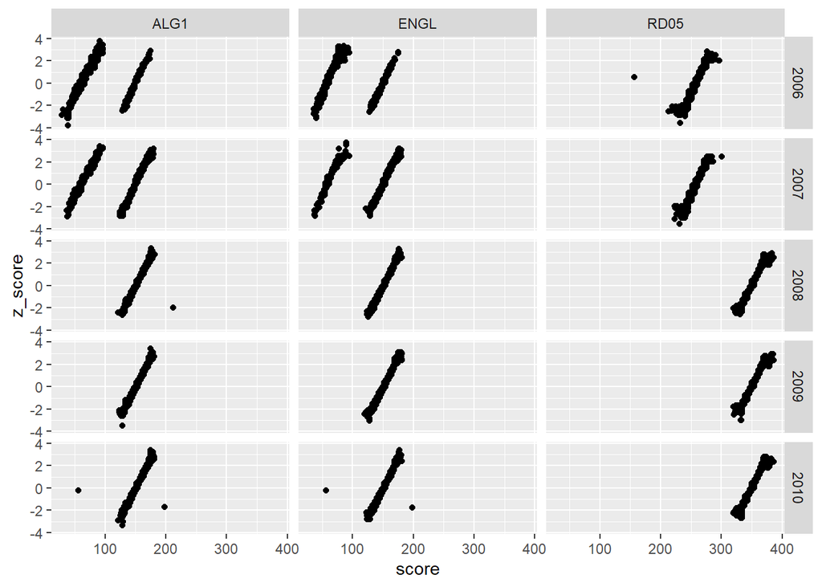

```r
library(ggplot2)
# Create a subset of the data to plot
plotdf <- stu_test %>% filter(test_id %in% c("ALG1", "RD05", "ENGL")) %>%
  dplyr::select(test_id, school_year, score, z_score) %>%
  as.data.frame() #add this to avoid errors related to incompatible datatypes when using %>%

ggplot(plotdf, aes(x = score, y = z_score)) +
  geom_point() + # make a scatterplot
  facet_grid(school_year~test_id) # facet the scatters by year and test subject
```

To examine the graphs, make the graph window full screen so it’s easier to see the individual graphs. The explanation for the low correlation is clear: the problematic tests and years appear to have two different score ranges. It’s likely that scores for two different versions of the tests were lumped together in the data. If you planned to use these tests in your analysis, you would need to find out more details about the test forms and versions for the problematic tests and years.

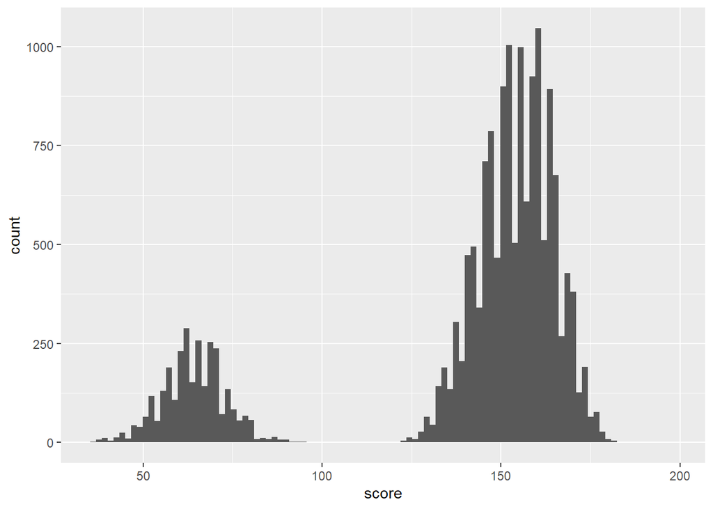

```r
ggplot(plotdf[plotdf$test_id == "ENGL", ],
       aes(x = score)) + geom_histogram(bins = 100)
```

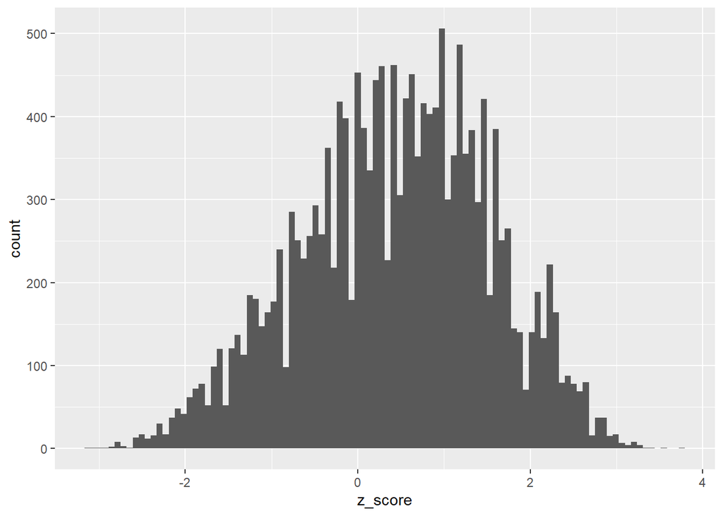

```r
ggplot(plotdf[plotdf$test_id == "ENGL", ],
       aes(x = z_score)) + geom_histogram(bins = 100)
```

You might wonder if you should use the z_score variable, rather than the scaled score, since it appears to correct for this problem. But you don’t know the details of how z_score was derived, and you saw in the correlation tables that it is missing for many tests. Even if the variable is fully populated for the tests you care about, as you have seen it might mask issues with those teststhat you should be aware of. You are better off using the scaled scores and examining them carefully for the tests you are interested in. After examining the scaled scores, you can derive your own standardized scores and use them to compare scores across tests and years.

For now, note that you should likely drop the z_score variables, and make a note to yourself to inquire about their provenance. When making notes to yourself, it’s a good idea to prefix them with a consistent symbol so that you can find them quickly. Here the follow-up reminder is preceded by `# TODO:`

```r
stu_test <- stu_test %>% dplyr::select(-keep, -row_count, -z_score, -z_score_err)
# TODO: consider dropping z_score here after learning more about how it was derived
```

## Reshape the Data

So, now that we’ve cleaned our rows and columns, and done some exploration, we are almost ready to analyze our data. Now we have to talk about the “shape” of our data, as much of our work as data analysts will be spent organizing tabular data into the correct format for the correct type of analysis. In general, R prefers data in a “long” format - that is, with as few columns as possible, and repeated entries for observations indicated by sequential variables.

That is how our data is currently constructed. We have student test scores, but our data only contains one column for scores, and other columns indicate which test and which year each score belongs to. This was called “tidy data” in the pre-readings. It is simply the method that most R analysis tools prefer to work with data.

Stata and other software packages sometimes prefer data in the wide format, where multiple measurements from the same observation are stored as different columns. Wide data might include each score for a student-year in a different variable/column - so our data would have “ALG2_score”, “MA10_score”, “CRD_SCORE”, etc. The result would be fewer rows but many more columns. However you are used to working with data - wide or long - you can be sure that you’ll have to be able to movedata between these two shapes, sometimes within the same analysis file.

So, let’s look at how we might go about reshaping our data.

1. Reshape only what is necessary
2. Lags and derived variables
3. Column naming and working with many columns

### Reshaping 101

The first and most important rule of reshaping is to only take what you need. Every variable you include in reshaping is another opportunity for problems to arise, so proceed with caution. A little bit of thinking upfront can save you a lot of possible debugging trying to get the reshaping commands to work later.

Reshaping is a complex process so we should approach it with the same caution and attention to detail we would approach specifying the functional form of a regression model. The more often you do this, the more comfortable you’ll become reshaping data.

But the first rule is take only what you need. To demonstrate this, let’s imagine that we want to create a dataset that includes a column for each assessment a student took in each year. So instead of our data being unique by sid-test_year-test_id we want the data to be unique by sid-test_year with multiple columns, one for each assessment.

If your data is small, you can guess and check with the reshaping commands and view your data until you get the shape right. This is an OK approach and one I use on quick projects all the time! But, when your data is larger and has a complex hierarchy like our data here, it can be helpful to think analytically about what exactly the current data looks like and what we expect the source data to look like.

In this case, the most important question is to think about how many columns we expect (e.g. how many unique assessments there are):

```r
length(unique(stu_test$test_id))
```

```
## [1] 37
```

We also want to think about how many rows we will lose. In essence, we should now have 1 row per student per year.

```r
dplyr::distinct(stu_test, sid, school_year) %>% nrow
```

```
## [1] 153455
```

A final caution - reshaping data is a great way to pressure test how clean your data really is. If you have repeated rows, duplicated data, or missing data in key columns the reshaping procedure can fail or produce a strange looking reshaped dataset that does not meet your expectations. When the reshaped data does not look like you would expect, consider the original data carefully. Do duplicate records exist? Does missing data appear in the identifier columns?

So now that we’ve set expectations, let’s give this a try. R provides two ways to reshape data, and I find myself using both interchangeably. Neither is ideal for every situation so we’ll demonstrate both here and you can choose for yourself which way feels more intuitive and understandable to you.

#### Long to Wide

In this code we will use the `tidyverse` package `tidyr` to reshape the data. When you want to reshape data from long to wide in `tidyr` you use the verb `spread()` - to spread your long data out across a wider area. The two arguments to `spread()` that control this are the name of the variable you want to use to name the wide columns (`test_id`) and the name of the value you want to put in each cell when you spread the data wide (`score`).

```r
# Method 1
library(tidyr)
stu_test %>% dplyr::select(sid, school_year, test_id, score) %>% # select the variables we want to move
  spread(test_id, score) -> test_wide # select which variable defines new columns, and which variable
# to fill those new columns with
str(test_wide)
```

```
## tibble [153,455 x 39] (S3: tbl_df/tbl/data.frame)
##  $ sid        : num [1:153455] 1e+08 1e+08 1e+08 1e+08 1e+08 ...
##  $ school_year: num [1:153455] 2006 2007 2008 2009 2010 ...
##  $ ALG1       : num [1:153455] NA NA 152 NA NA 133 NA NA NA NA ...
##  $ ALG2       : num [1:153455] NA NA NA NA 148 NA NA NA NA 162 ...
##  $ BIOL       : num [1:153455] NA NA NA 151 NA NA NA NA 71 NA ...
##  $ CECO       : num [1:153455] NA NA 153 NA NA NA NA NA 145 NA ...
##  $ CHEM       : num [1:153455] NA NA NA NA NA NA NA NA NA NA ...
##  $ COMP       : num [1:153455] NA 152 NA NA NA NA NA NA NA NA ...
##  $ CSCM       : num [1:153455] NA NA NA NA NA NA NA NA NA NA ...
##  $ CSKA       : num [1:153455] NA NA NA NA NA NA NA NA NA NA ...
##  $ CSPF       : num [1:153455] NA NA NA NA NA NA NA NA NA NA ...
##  $ CTAM       : num [1:153455] NA NA NA NA NA NA NA NA NA NA ...
##  $ CTAR       : num [1:153455] NA NA NA NA NA NA NA NA NA NA ...
##  $ ENGL       : num [1:153455] NA NA 148 NA NA 136 NA NA NA NA ...
```

[output cut: 25 more lines]

The data came out in exactly the shape we expected - how great! In this code we reduced our data to only the variables we wanted to retain. Then we told R to spread the `score` variable out wide by the values of the `test_id` column. So for each unique value of `test_id` R made a new column, and where there was a `score` for that `test_id` it filled that value in. Where there was no score for that `test_id` R filled in missing data, `NA`. Optionally, we could fill this data in with 0s instead, if that was more appropriate for our data.

In base R, without loading or installing any packages, we have a powerful reshape function. This function was originally intended to reshape time series data, so the function arguments are less intuitive. In this case, we define the data we want to reshape, we tell the function which variables will make a unique row in the reshaped data (`idvar = c("sid", "school_year")`, we define the variable to use in labeling the new columns (`timevar = c("test_id"))`), and we specify the direction we want to shift the data - in this case to wide.

> reshape() allows us to reshape multiple variables at a time more easily than `tidyr`, but it also has very difficult to decipher error messages. A good pattern if you find yourself using `dplyr` to manipulate data is to always remember to set your data back as a `data.frame` before using `reshape`. This command takes almost no time to execute, and it will eliminate the chance for time consuming errors in the reshaping of the data

```r
# Method 2
## Reset the data as a dataframe
stu_test <- as.data.frame(stu_test)
test_wide <- reshape(data = stu_test[, c("sid", "school_year", "test_id", "score")], #subsset only
                     # the variables we want to use
                     idvar = c("sid", "school_year"), # variables that do not chance
                     timevar = "test_id", # the variable we want to turn into columns
                     direction = "wide") # tell reshape which direction we are shifting the data to
```

Inspect the result for yourself, you’ll see the identical result is produced. Which you use is up to you and what works best for your needs. I find myself moving seamlessly back and forth between them - depending on the project, data I am working with, and my analytic goals.

#### Wide to Long

Sometimes you will be given data that is wide - survey questions or multiple assessment scores per student record for example - and you’ll want to shape that data to be long. We can use the same two approaches above, with modifications, to go back from wide to long.

To go in this direction, we use a different verb from `tidyr` - `gather()`. In this case, we are gathering up several columns and reshaping them into just two - a `key` column and a `value` column. The `key` column defines how we will differentiate between the multiple columns in the wide format. The `value` column stores the value for each different column, now in a single column.

In this case, we define our `key` variable to be `test_id` - in gather we are just choosing the name for the `key` and `value` columns, and we can make them whatever we want. We call the `value` column `score`. Now, there is one additional argument to `gather()`, which is that we need to tell it which columns we wish to gather up and reshape long. The `tidyverse` packages have a number of helpful ways of selecting column names - check out the documentation for some great examples. In this case I just deselect (using `-`) the two identifier columns, so the function will then `gather()` up the rest.

```r
# Method 1
test_wide %>%  # select the variables we want to move
  gather(key = "test_id", value = "score",
         -sid, -school_year) -> test_long # select which variable defines new columns, and which variable
# to fill those new columns with
str(test_long)
```

```
## 'data.frame':    5677835 obs. of  4 variables:
##  $ sid        : num  1e+08 1e+08 1e+08 1e+08 1e+08 ...
##  $ school_year: num  2006 2006 2006 2006 2006 ...
##  $ test_id    : chr  "score.RD07" "score.RD07" "score.RD07" "score.RD07" ...
##  $ score      : num  267 NA NA NA NA NA NA NA NA NA ...
```

With `reshape()` we specify our `idvar` and set the direction to long, and let the function do the rest. One thing we may have to do is clean up the row.names and the column names of the reshaped data.

```r
# Method 2
test_long <- reshape(test_wide, idvar = c("sid", "school_year"),
                     timevar = "test_id",
                     direction = "long")
str(test_long)
```

```
## 'data.frame':    5677835 obs. of  4 variables:
##  $ sid        : num  1e+08 1e+08 1e+08 1e+08 1e+08 ...
##  $ school_year: num  2006 2006 2006 2006 2006 ...
##  $ test_id    : chr  "RD07" "RD07" "RD07" "RD07" ...
##  $ score.RD07 : num  267 NA NA NA NA NA NA NA NA NA ...
##  - attr(*, "reshapeLong")=List of 4
##   ..$ varying:List of 1
##   .. ..$ 1: chr [1:37] "score.RD07" "score.WR07" "score.MA07" "score.MA03" ...
##   ..$ v.names: NULL
##   ..$ idvar  : chr [1:2] "sid" "school_year"
##   ..$ timevar: chr "test_id"
```

In both cases, the data reshaped long is now longer than our original data. We have padded each student record with NA values for every combination of `test_id` and `school_year`. Both reshape methods allow you to drop these extra observations.

Reshaping can become more complex when you want to reshape multiple variables at the same time, you have a complicated uniqueness structure to your data, or you need to retain missing data in some specific ways - but this is a good introduction to the basics!

```r
# clean up this extra data
rm(test_long, test_wide, plotdf)
```